# Fiche espèce - Paon du jour

# Filtres généraux

- Suppression des départements en NA
- Suppression des départements avec plus de 2 caractères (suppression des drom-com)
- Suppression des dates antérieures au 1 janvier 2005 si données historiques, sinon 1 janvier 2019
- Suppression des observations ne concernant pas des taxons de la liste principale (Machaons,Flambés, Demi-deuils, Paon du jour, Vulcain, Belle-dame, Petites tortues, Robert-le-diable, Tabac d’Espagne, Silène, Sylvains, Souci, Aurores, Piérides blanches,Gazé,Citrons,Amaryllis, Myrtil, Procris, Mégères, Tircis, Lycènes bleus, Argus verts, Brun des pélargoniums, Cuivré, Hespérides tachetées, Hespérides orangées, Moro-sphinx)

2 data frame :

- un data frame de toutes les observations (df_opj)
- un data frame avec uniquement le taxon de la fiche (df_sp)

## Images

### Photo

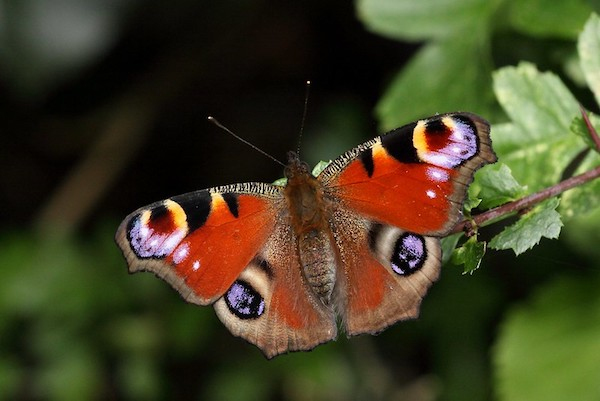

### Logo

[figure not shown]

# Chiffres clés

## Infobulle 1 (observations)

- Filtre sur les données où l’abondance est strictement supérieure à 0 sur df_sp puis comptage du nombre de lignes

Nombre de fois où au moins un individu a été observé :

54 130 sur 216 020 observations

## Infobulle 2 (abondance)

- Filtre sur les données où l’abondance est strictement supérieure à 0 sur df_sp puis somme de toutes les abondances

Les participants ont compté 125 150 Paon du jour sur les 2 089 280 papillons au total.

## Distribution abondance entre espèces

- On a besoin des noms des taxons et des abondances correspondantes.
- On groupe par taxon et on somme les abondances de chaque taxon. On divise ensuite les abondances de chaque taxon par l’abondance totale de tous les taxons.

**2019-2024**

[interactive chart not shown]

**2006-2018**

[interactive chart not shown]

**2006-2024**

[interactive chart not shown]

- **Titre :** Répartition de l’abondance observée selon les différentes espèces et groupes d’espèces parmi toutes les observations de l’Opération papillons.
- **Explication :** Quelles sont les espèces ou groupes d’espèces les plus observés par les participants et participantes ? On cherche ici à montrer la part que représente chaque espèce si l’on considère l’ensemble des individus comptés dans l’Opération papillons. Sur cette figure chacune des barres représente le pourcentage de l’abondance totale observée pour une espèce donnée.

En lisant la figure on peut observer que le classement de l’espèce parmi les 28 espèces de la liste principale : 9/28

**Interprétation**

Ajouter une explication sur les Piérides Blanches qui constituent la majeure partie des observations ? Ajouter interprétation ad hoc pour l’espèce ciblée ?

Ajouter des éléments en lien avec les risques de confusion ? Et le fait qu’on prend en compte l’ensemble des données, dont les participations “one shot” c’est-à-dire les participant.es qui n’ont enregistré qu’une participation

**Fonctionnalités souhaitées**

Avoir de l’information précise en survolant une colonne, comme par exemple la valeur exacte du pourcentage, dans une phrase du style “Les Lycènes bleus regroupent XX% des individus comptés dans le cadre de l’Opération papillons”.

Ajouter des informations sur le graphique pour distinguer les espèces communes des espèces rares ? (comme c’est le cas pour l’instant avec le dégradé de bleu)

# Cartographie

**Fonctionnalités souhaitées**

Si on décide d’avoir une partie avec des cartes : carroussel pour les cartes avec à chaque fois la carte et un encart avec un texte explicatif à côté

## Jardins

- On remplace par les raster
- Depuis le df_sp, on a besoin des jardins, de leur latitude, longitude et de l’abondance du taxon
- On groupe par jardin et on somme l’abondance. On divise ensuite en deux catégories : observé (> 0) et non observé (= 0)

**2019-2024**

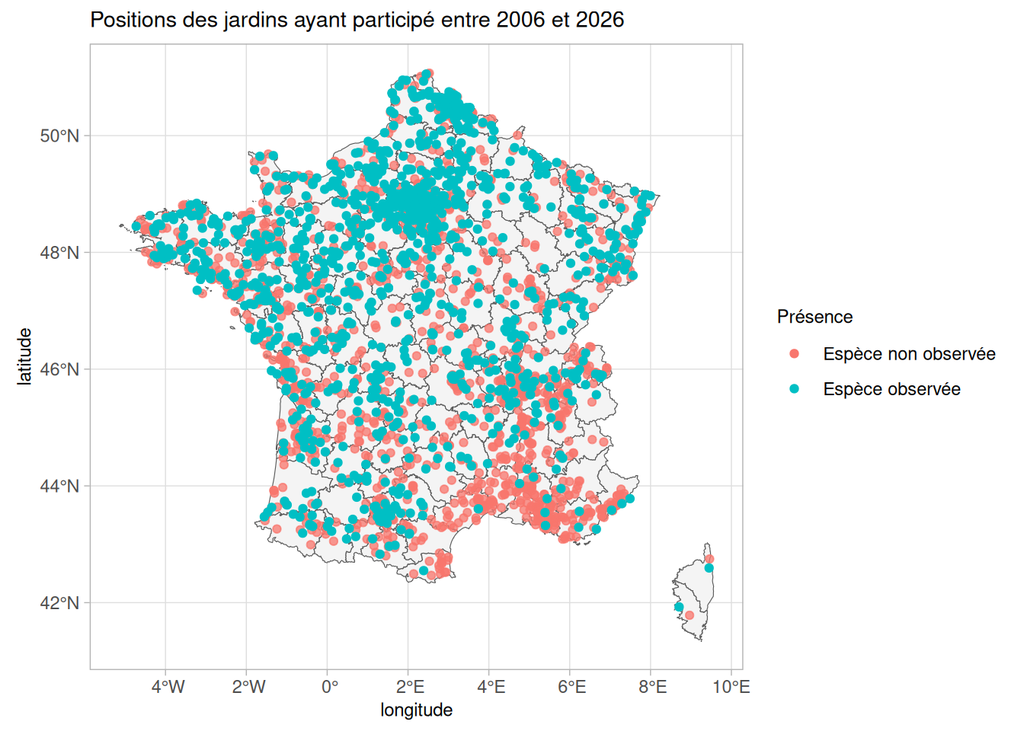

**2006-2018**

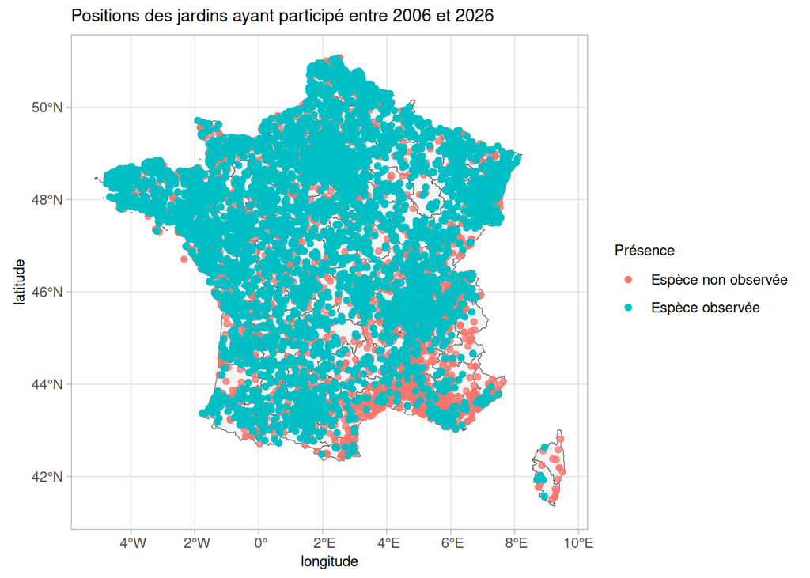

**2006-2024**

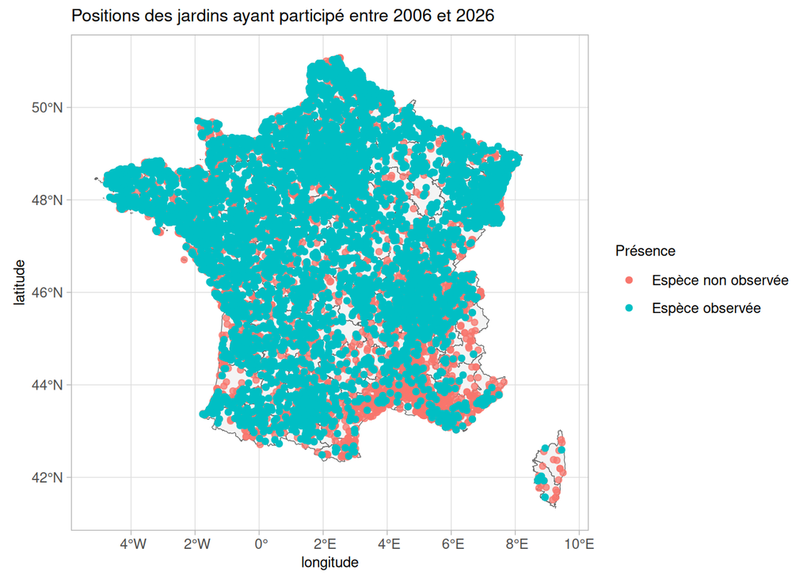

- **Titre** : Carte des jardins participants à l’Opération papillons ayant observé l’espèce au moins une fois
- **Explication** : Où observe-t-on cette espèce ? Chaque point sur la carte représente un jardin participant à l’Opération papillons. Les points rouges représentent les jardins où l’espèce n’a pas été observée, et les points verts représentent les jardins ayant observé au moins une fois cette espèce.

**Interprétation**

Interprétation : Insister sur le fait que certains jardins n’ont participé qu’une seule semaine, et faire le lien avec la probabilité d’observation.

Faire le lien avec ce qu’on connaît de la distribution de l’espèce ?

**Fonctionnalités souhaitées**

Pouvoir zoomer/dézoomer sur la carte. Afficher de l’information en survolant/cliquant sur un point avec par exemple le nombre d’année de participation et le nombre de sessions d’observation (nombre de fois où le jardin a transmis les données).

## Carte raster

Nouveau type de représentation de la cartographie

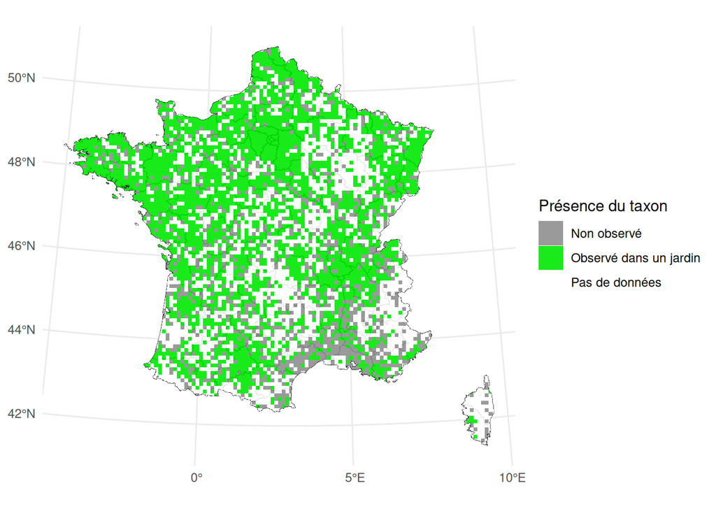

# Phénologie inter-annuelle

## Abondance relative

- Depuis df_sp, on groupe par date. On somme l’abondance, le nombre d’observations (toutes les observations où l’abondance du taxon est supérieure à 0), et le nombre de sessions uniques. On calcule ensuite l’abondance relative en divisant la somme d’abondance par le nombre de sessions.

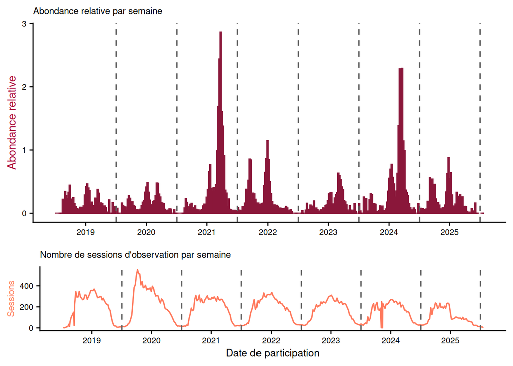

**2006-2018**

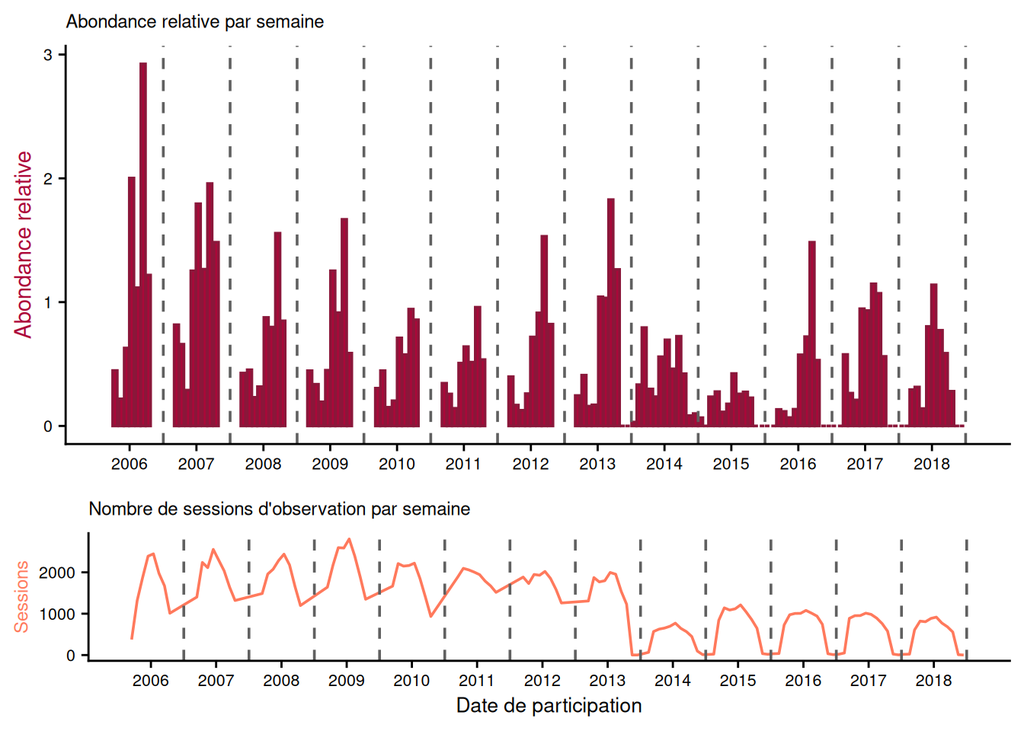

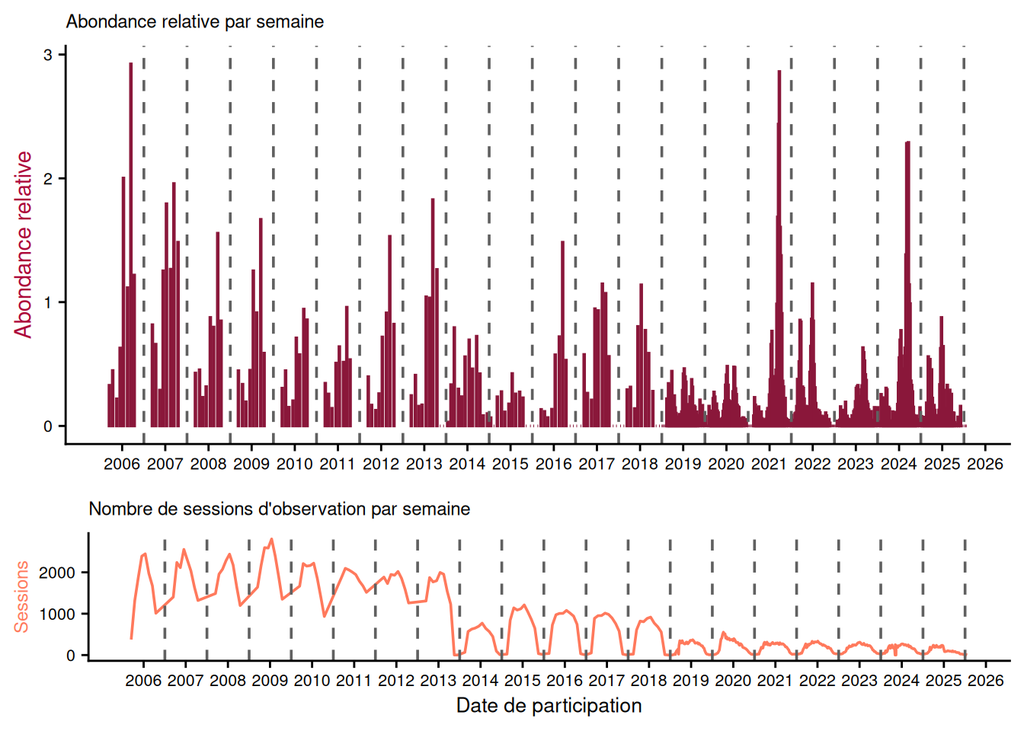

- **Titre** : Variations de l’abondance de l’espèce au cours du temps (en rouge en haut), et variations du nombre de participations (en orange en bas)
- **Explication** : Les deux graphiques permettent de visualiser la variation de l’abondance observée pour l’espèce au fil du temps. Les variations sont mesurées à la semaine. Nous affichons ici l’abondance “relative” c’est à dire en prenant en compte le nombre de jardins ayant participé cette semaine. Comme le montre le graphique du bas, le nombre de participations individuelles à l’Opération papillons varie au cours de l’année, atteignant souvent un pic durant l’été, à l’exception de l’année 2020 qui a connu une forte participation pendant le premier confinement dû à la pandémie. Pour rendre l’information comparable d’une semaine à l’autre et entre les années, nous divisions, chaque semaine, le nombre d’individus renseignés par le nombre de jardins actifs.

**Interprétation**

Ici il faudra décliner en fonction des espèces et des patterns (ex : Belle-Dame avec les fortes variations inter-annuelles)

**Fonctionnalités souhaitées**

Avoir un slider pour visualiser seulement une fenêtre parmi les années (important si on arrive à intégrer l’ensemble des données).

# Phénologie intra-annuelle

- Même data frame qu’au dessus

## Indicateurs relatifs

**Fréquence relative**

**2019-2024**

[interactive chart not shown]

**2006-2018**

[interactive chart not shown]

**2006-2024**

[interactive chart not shown]

**Abondance relative**

**2019-2024**

[interactive chart not shown]

**2006-2018**

[interactive chart not shown]

**2006-2024**

[interactive chart not shown]

**Biogéorégions (fréquence relative)**

**2019-2024**

[interactive chart not shown]

**2006-2018**

[interactive chart not shown]

**2006-2024**

[interactive chart not shown]

**Biogéorégions (abondance relative)**

**2019-2024**

[interactive chart not shown]

**2006-2018**

[interactive chart not shown]

**2006-2024**

[interactive chart not shown]

- **Titre** : Variations de la présence de l’espèce dans les jardins au cours de l’année.
- **Explication** : Chaque courbe de couleur représente la variation de la présence de l’espèce suivant les semaines sur une année (l’année en cours est affichée en rouge). Pour chaque semaine on calcule la proportion de jardins ayant observé l’espèce parmi l’ensemble des jardins ayant participé cette semaine-là. Cette proportion de jardins où l’espèce a été observée, notée fréquence relative sur le graphique, permet de mieux comprendre la phénologie de l’espèce. On peut ainsi observer la période à laquelle elle est la plus observée et donc la plus active.

**Interprétation**

Faire le lien avec les conseils sur la période d’observation ? Insister sur les données “aberrantes” en indiquant qu’il y a peu de chance qu’un individu ait pu être obsevé en hiver, et rassurer en indiquant que c’est un élément qu’on prend en compte au moment d’analyser les données.

Ajouter une phrase générique quand on sait qu’il y a plus d’une génération dans l’année.

**Fonctionnalités souhaitées**

Pouvoir facilement différencier les années sur le graphique, potentiellement cocher/décocher les années pour les faire apparaît ou non.

# Grégarité

- On considère le nombre d’individus vus en même temps comme une catégorie, et on compte le nombre de sessions rattachées à chaque catégorie. Ensuite on divise en trois catégories (1 / 2 à 4 / 5 et +) et dans le graphique on fait un histogramme pour chaque catégorie.

## Classes d’abondance pour l’espèce

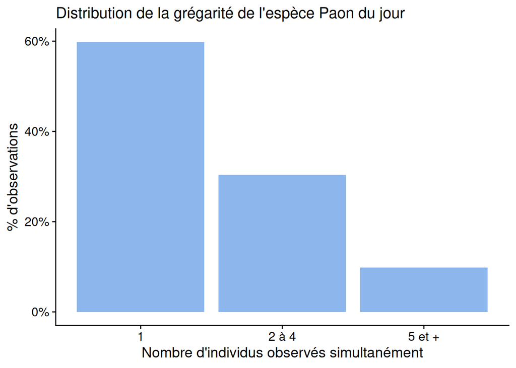

**Interprétation**

Pour l’Amaryllis il y a clairement un patron à interpréter mais je ne sais pas trop comment interpréter le reste, notamment concernant les espèces les plus rares/moins observées.

**Fonctionnalités souhaitées**